# Simulasi dan Identifikasi Proses MA(2), AR(2), dan ARMA(2,2) di R (Manual vs `arima.sim`)

Muhammad Hafiz Fazli

2025-09-25

```r
set.seed(1618)
library(TSA)
```

# Proses MA(2): theta1 = 0.4, theta2 = 0.6

## Pembangkitan Data

### Manual

```r
n <- 300
theta1 <- 0.4
theta2 <- 0.6

wn <- rnorm(n + 2, mean = 0, sd = 1)

ma2 <- numeric(n)
ma2[1] <- wn[3] + theta1 * wn[2] + theta2 * wn[1]
ma2[2] <- wn[4] + theta1 * wn[3] + theta2 * wn[2]

for(i in 3:n){
  ma2[i] <- wn[i+2] + theta1 * wn[i+1] + theta2 * wn[i]
}

ma2
```

```
##   [1] -1.1826040944  0.0947277037 -1.8720490354  0.6167616307 -1.4259924828
##   [6]  0.8562794342  0.1744981767  0.5258033094 -0.7840313923  0.9792076270
##  [11] -0.6081343488  0.8099057965 -0.3293457957  0.8959724583 -0.2378312932
##  [16]  0.8437181142 -1.4527404071 -0.3151310968  1.1874861400 -1.4616876908
##  [21] -1.3525662353 -2.2020744695 -0.9231081641  0.2540747545 -0.0267058061
##  [26]  1.0486651311  0.0379301127  1.7128394344 -1.3786873421  2.3214883875
##  [31] -2.0900351901  0.3021289175 -3.5814158598 -2.3775625285 -2.0636841589
##  [36]  0.4880055594  0.6351946850  1.4416504206  2.2565033835  2.6642161047
##  [41]  0.2298514978 -1.9909600687 -2.8915870987 -5.3091280059 -2.7471561564
##  [46] -2.0629088376 -1.5332106397 -1.6139461675 -3.0521557831 -1.0891741174
##  [51] -2.3297623220 -1.0534448164 -0.2438835356  2.5599579348  0.1871481821
##  [56] -0.0309870362 -0.7098260228 -1.0169316416 -0.3828831313 -0.0776262372
##  [61]  0.6229766830  1.0824789382 -1.3784656490  0.2301593169 -1.7883306741
##  [66] -0.0994347308 -0.6073920023 -1.1266012960 -0.4337329926 -0.0807776084
##  [71]  0.4190416520 -0.6075357719 -1.6319080796 -1.6086470417 -0.7127302456
```

[output cut: 45 more lines]

### Dengan `arima.sim`

```r
ma2_sim <- arima.sim(list(order = c(0,0,2), ma = c(theta1, theta2)), n = n)
ma2_sim
```

```
## Time Series:
## Start = 1
## End = 300
## Frequency = 1
##   [1] -1.398490501  1.093151043 -0.037199886  2.505589775  1.007925916
##   [6] -0.304682725  0.839351418 -0.491458698  0.972963646  0.935394078
##  [11]  0.296743364  1.453520064  0.418884998  0.742921829  1.067906417
##  [16]  0.376896673  0.134196471 -0.427053688 -0.774602587 -0.850716887
##  [21] -1.387686951 -1.628012925 -0.972962702 -1.178204840 -1.811965331
##  [26] -2.673205097 -1.367943718 -2.023075631  0.316076530 -0.359622942
##  [31]  0.005768532 -1.346480257  0.278149859 -0.546681214 -1.205942216
##  [36]  0.434162921  0.162923462  0.875652933  0.507926100 -0.144793405
##  [41] -0.858149096 -2.121979505 -0.681983849  1.718726803  0.522388841
##  [46]  1.027170793 -0.350662411  0.490405026  0.113973781 -0.658573832
##  [51]  0.184411196  0.060488372  1.031554936 -1.264683360 -0.382217049
```

[output cut: 49 more lines]

## Plot Time Series, ACF, PACF, dan EACF

### Plot Time Series

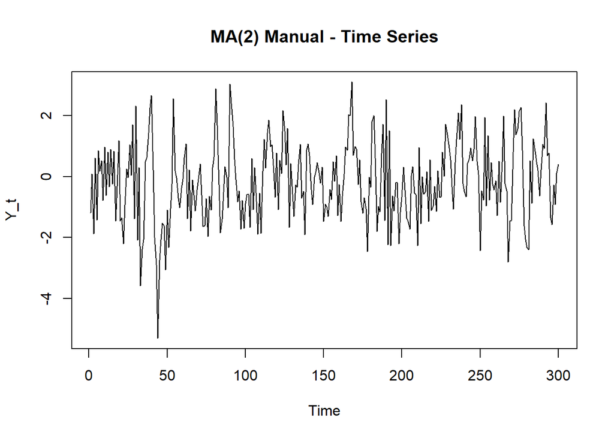

```r
ts.plot(ma2, main = "MA(2) Manual - Time Series", ylab = "Y_t")
```

> Berdasarkan plot time series, terlihat bahwa data MA(2) yang dibangkitkan stasioner dalam rataan karena nilai-nilai berfluktuasi di sekitar rata-rata tetap dan tidak menunjukkan adanya tren naik atau turun jangka panjang.

### Plot ACF

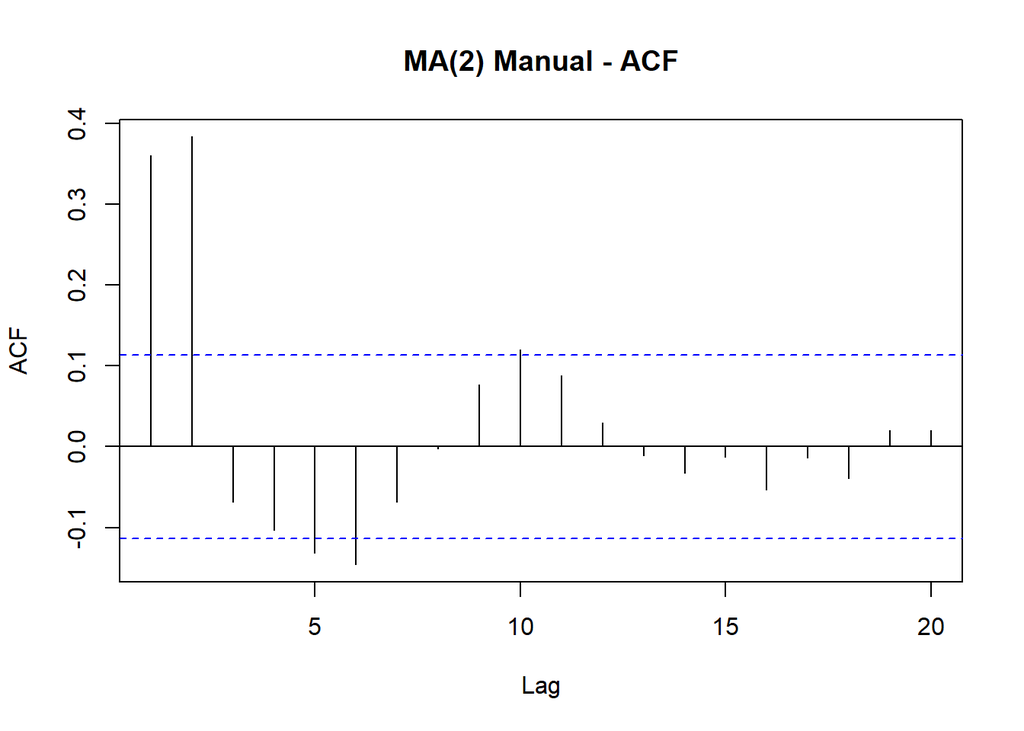

```r
acf(ma2, lag.max = 20, main = "MA(2) Manual - ACF")
```

> Berdasarkan plot ACF tersebut, terlihat bahwa plot ACF cut off sampai lag kedua, sesuai dengan karakteristik proses MA(2). Setelah lag kedua, nilai autokorelasi turun mendekati nol.

### Plot PACF

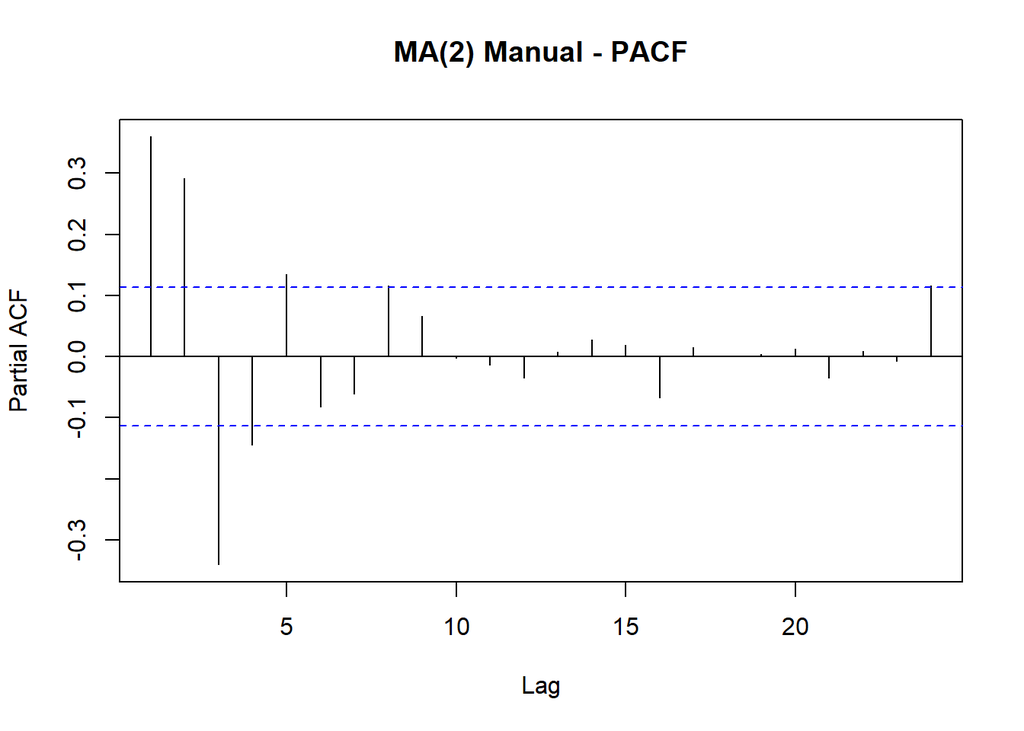

```r
pacf(ma2, main = "MA(2) Manual - PACF")
```

> Berdasarkan plot PACF tersebut, terlihat bahwa plot PACF cenderung tails off dan membentuk gelombang sinus, sesuai dengan karakteristik proses MA.

### Plot EACF

```r
TSA::eacf(ma2)
```

```
## AR/MA
##   0 1 2 3 4 5 6 7 8 9 10 11 12 13
## 0 x x o o x x o o o x o  o  o  o
## 1 x x x o o o o o o o o  o  o  o
## 2 x x x o o o o o o o o  o  o  o
## 3 x x x o o o o o o o o  o  o  o
## 4 x o x x x o o o o o o  o  o  o
## 5 x x x x x o x o o o o  o  o  o
## 6 x x x x o o o o o o o  o  o  o
## 7 x x x x x o o o o o o  o  o  o
```

## Scatterplot Lag dan Autokorelasi

### Yt vs Yt-1

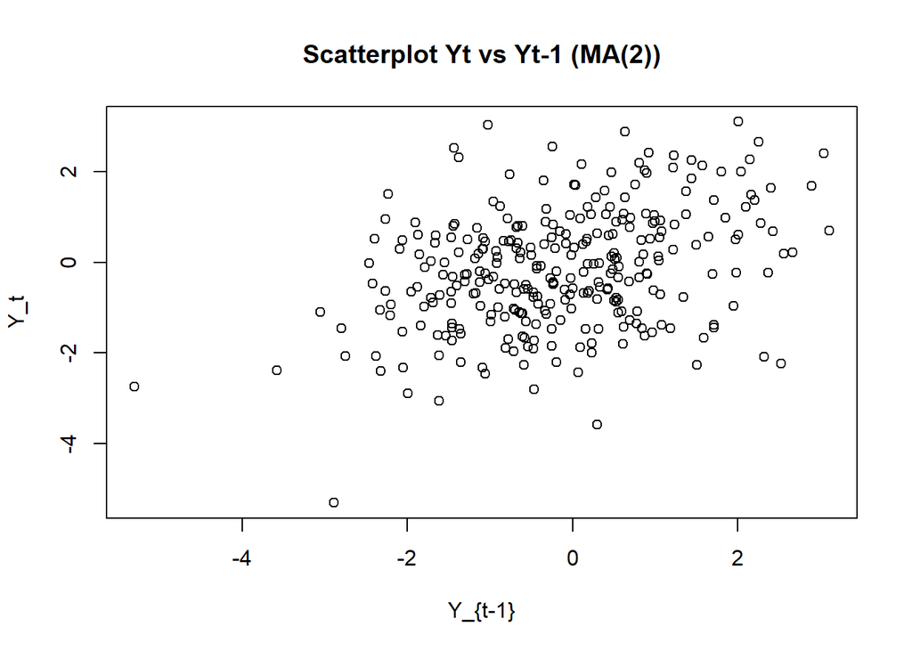

```r
yt_ma2 <- ma2[-1]

yt_1_ma2 <- ma2[-300]

plot(y = yt_ma2, x = yt_1_ma2,
     main = "Scatterplot Yt vs Yt-1 (MA(2))",
     xlab = "Y_{t-1}", ylab = "Y_t")
```

```r
cor(yt_ma2, yt_1_ma2)
```

```
## [1] 0.3602594
```

Secara teoritis, autokorelasi lag-1 untuk MA(2) adalah:

$$\rho_1 = \frac{\theta_1 + \theta_1 \theta_2}{1 + \theta_1^2 +
\theta_2^2}
= \frac{0.4 + (0.4 \times 0.6)}{1 + 0.4^2 + 0.6^2}
= \frac{0.64}{1.52}
\approx 0.421$$

Nilai korelasi dari simulasi (0.360) cukup mendekati nilai teoritis 0.421.

### Yt vs Yt-2

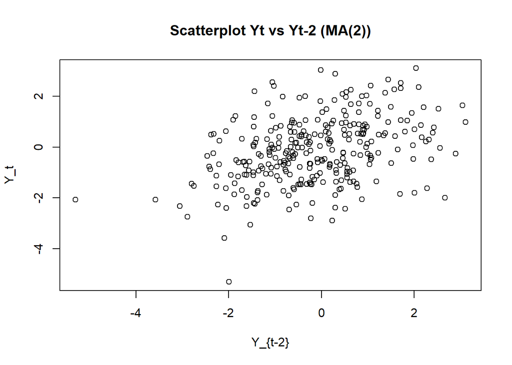

```r
yt_ma2 <- ma2[-c(1,2)]

yt_2_ma2 <- ma2[-c(299,300)]

plot(y = yt_ma2, x = yt_2_ma2,
     main = "Scatterplot Yt vs Yt-2 (MA(2))",
     xlab = "Y_{t-2}", ylab = "Y_t")
```

```r
cor(yt_ma2, yt_2_ma2)
```

```
## [1] 0.3837528
```

Secara teoritis, autokorelasi lag-2 untuk MA(2) adalah:

$$\rho_2 = \frac{\theta_2}{1 + \theta_1^2 + \theta_2^2}
= \frac{0.6}{1 + 0.4^2 + 0.6^2}
= \frac{0.6}{1.52}
\approx 0.395$$

Nilai korelasi dari simulasi (0.384) cukup mendekati nilai teoritis 0.395.

### Yt vs Yt-3

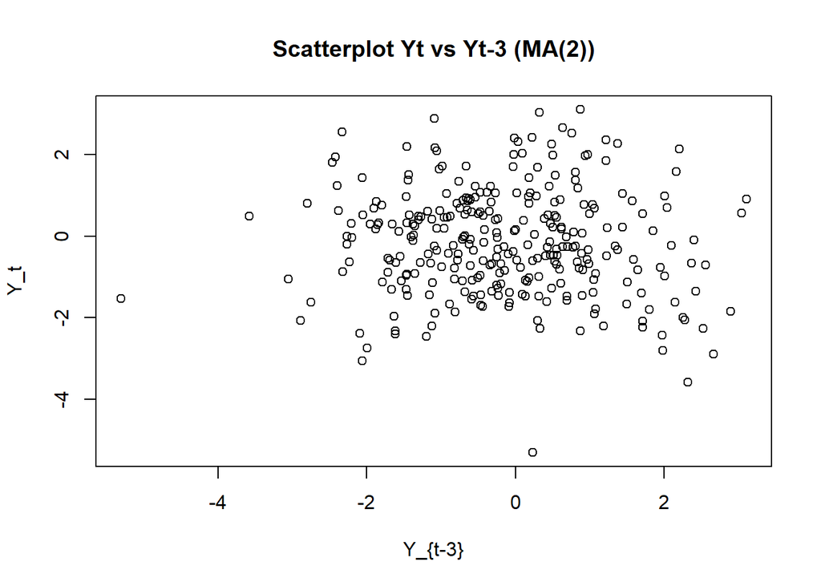

```r
yt_ma2 <- ma2[-c(1,2,3)]

yt_3_ma2 <- ma2[-c(298,299,300)]

plot(y = yt_ma2, x = yt_3_ma2,
     main = "Scatterplot Yt vs Yt-3 (MA(2))",
     xlab = "Y_{t-3}", ylab = "Y_t")
```

```r
cor(yt_ma2, yt_3_ma2)
```

```
## [1] -0.06895057
```

Secara teoritis, autokorelasi lag-3 untuk MA(2) adalah 0, karena MA(2) hanya memiliki autokorelasi hingga lag 2.

Nilai korelasi dari simulasi (-0.069) cukup mendekati nilai teoritis 0.

# Proses AR(2): phi1 = 0.5, phi2 = 0.2

## Pembangkitan Data

### Manual

```r
n <- length(wn)
n
```

```
## [1] 302
```

```r
ar2 <- c(1:n)
ar2[1] <- wn[1]
ar2[2] <- wn[2] + 0.5*ar2[1]

for (i in 3:n) {
  ar2[i] <- wn[i] + 0.5*ar2[i-1] + 0.2*ar2[i-2]
}

ar2
```

```
##   [1] -0.762350446 -0.792883308 -1.109422336 -0.147331038 -2.057675383
##   [6] -0.076266185 -1.211200499 -0.049183749  0.135917706  0.079823698
##  [11] -0.967266448  0.912262921 -0.276811637  0.241789642 -0.019216568
##  [16]  0.849976001 -0.090327712  0.686402604 -1.045349712 -0.489273999
##  [21]  1.597622347 -1.518935234 -2.135350313 -1.563438842 -1.037862693
##  [26] -0.530729094 -0.722554974  0.500554968 -0.093723974  1.265097662
##  [31] -1.129928490  1.979927492 -1.196566508 -0.491074339 -2.774428964
##  [36] -2.773894531 -2.116384049 -0.282065866 -0.356746489  0.325295663
##  [41]  1.999231133  2.629668516  0.173774896 -1.700772972 -1.857237603
##  [46] -4.773102489 -3.478459627 -2.365977348 -3.110763908 -3.346414045
##  [51] -4.081130954 -2.294011970 -3.387866334 -2.885828504 -1.216353382
##  [56]  1.452817654 -0.927458168 -1.222810089 -0.240507096 -0.974516318
##  [61] -1.008196158 -0.221672496  0.403271612  0.667084100 -1.597630649
##  [66]  0.063621945 -1.160557798 -0.755264454 -0.618346227 -1.470760358
##  [71] -0.883407211 -0.200569559 -0.057424345 -1.085350278 -1.911183536
```

[output cut: 46 more lines]

### Dengan `arima.sim`

```r
ar2_sim <- arima.sim(list(order = c(2,0,0), ar = c(0.5, 0.2)), n = 200)
ar2_sim
```

```
## Time Series:
## Start = 1
## End = 200
## Frequency = 1
##   [1] -1.794454588  0.685808712 -1.630063709 -1.693471464 -1.849259990
##   [6] -1.368401735 -1.482322362 -0.091187955 -1.647350398 -0.518012948
##  [11] -0.560039947 -1.415339234  0.041892931  0.077496168 -0.513206576
##  [16]  0.599319489  0.330662667 -0.287450087  0.004784934  0.056602239
##  [21]  1.080893782  0.837754330  0.358505221  1.034962004  0.613742117
##  [26]  0.655368671  1.185990552  0.957381063  1.237641414  2.607873201
##  [31]  0.435330885  0.391406464 -0.481762286 -0.936561647 -1.086449069
##  [36] -2.459067541 -1.194047341 -0.661482870 -1.644086132 -0.539142873
##  [41] -0.333353305 -1.588414795  0.336370684 -1.037725169 -3.017582671
##  [46] -3.217139104 -1.722034019 -1.210871921  0.803559623  1.780235017
##  [51] -0.418027136  0.277200233  0.998075738 -1.194507056 -0.191677282
```

[output cut: 29 more lines]

## Plot Time Series, ACF, PACF, dan EACF

### Plot Time Series

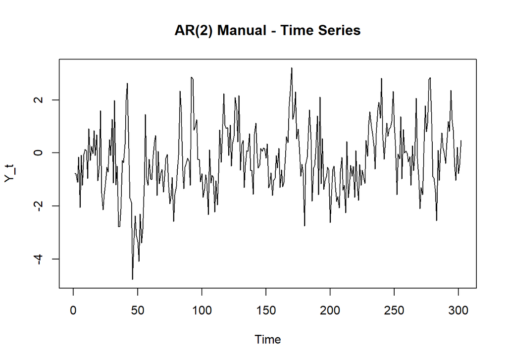

```r
ts.plot(ar2, main = "AR(2) Manual - Time Series", ylab = "Y_t")
```

> Berdasarkan plot time series, terlihat bahwa data AR(2) yang dibangkitkan stasioner dalam rataan karena nilai-nilai berfluktuasi di sekitar rata-rata tetap dan tidak menunjukkan adanya tren naik atau turun jangka panjang.

### Plot ACF

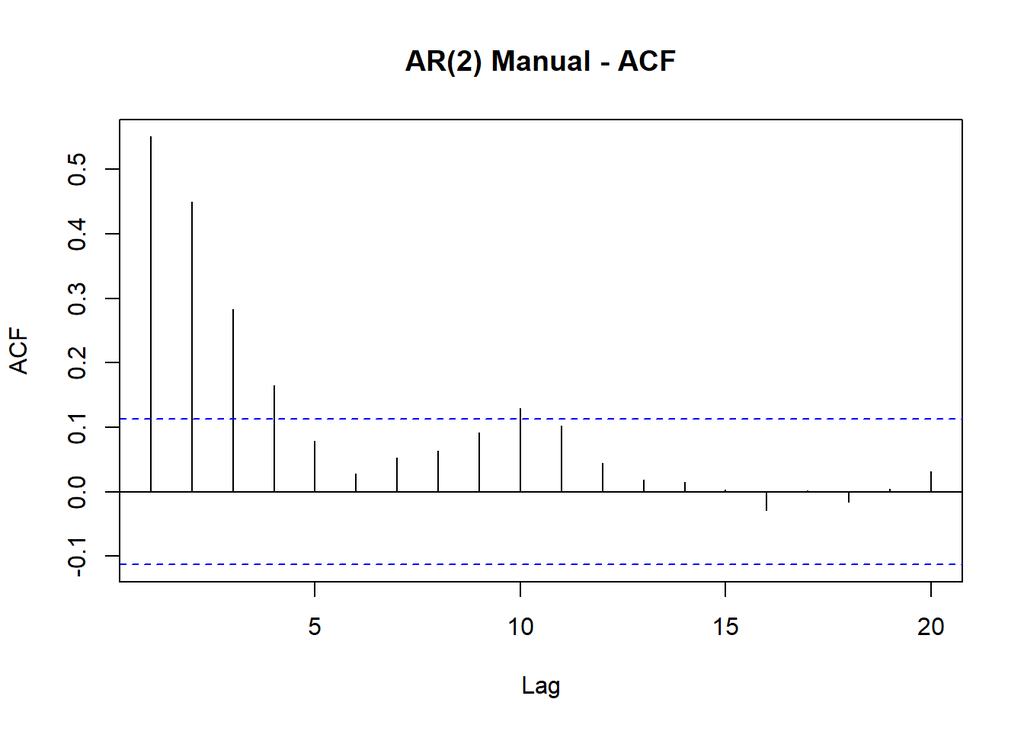

```r
acf(ar2, lag.max = 20, main = "AR(2) Manual - ACF")
```

> Berdasarkan plot ACF tersebut, terlihat bahwa plot ACF cenderung tails off dan membentuk gelombang sinus, sesuai dengan karakteristik proses AR.

### Plot PACF

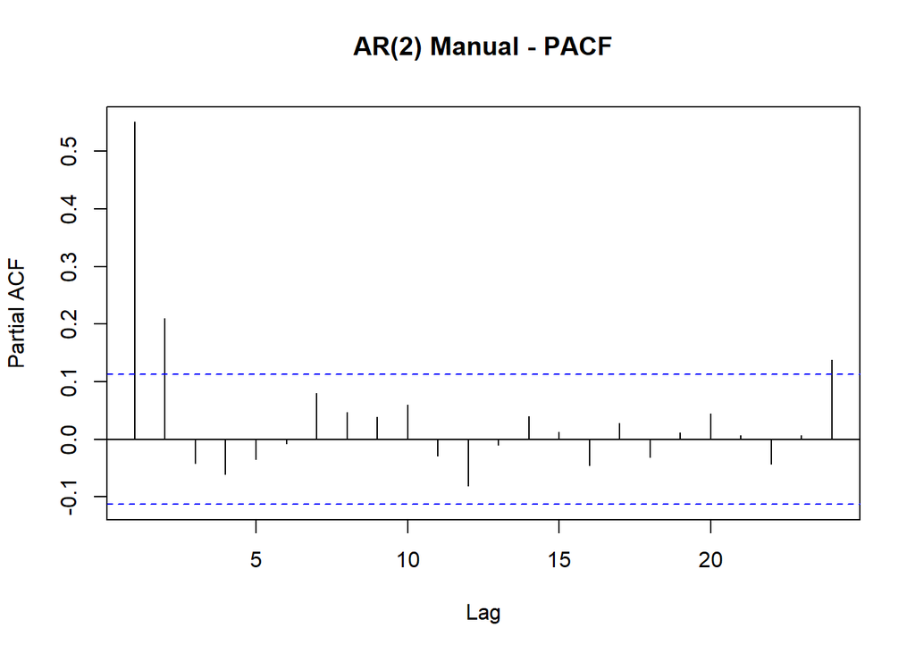

```r
pacf(ar2, main = "AR(2) Manual - PACF")
```

> Berdasarkan plot PACF tersebut, terlihat bahwa plot PACF cut off sampai lag kedua, sesuai dengan karakteristik proses AR(2). Setelah lag kedua, nilai parsial autokorelasi turun mendekati nol.

### Plot EACF

```r
TSA::eacf(ar2)
```

```
## AR/MA
##   0 1 2 3 4 5 6 7 8 9 10 11 12 13
## 0 x x x x o o o o o x o  o  o  o
## 1 x x o o o o o o o o o  o  o  o
## 2 x x o o o o o o o o o  o  o  o
## 3 x o o o o o o o o o o  o  o  o
## 4 x x o o o o o o o o o  o  o  o
## 5 x o x o x o o o o o o  o  o  o
## 6 o x x x x o o o o o o  o  o  o
## 7 x o x x x o o o o o o  o  o  o
```

## Scatterplot Lag dan Autokorelasi

### Yt vs Yt-1

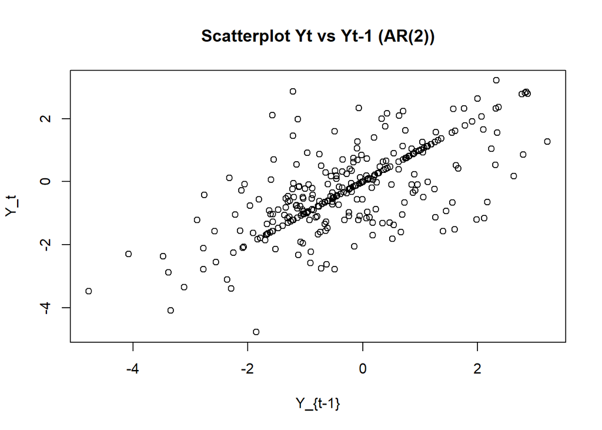

```r
yt_ar2 <- ar2[-1]
yt_1_ar2 <- ar2[-200]

plot(y = yt_ar2, x = yt_1_ar2,
     main = "Scatterplot Yt vs Yt-1 (AR(2))",
     xlab = "Y_{t-1}", ylab = "Y_t")
```

```r
cor(yt_ar2, yt_1_ar2)
```

```
## [1] 0.6732971
```

Secara teoritis, autokorelasi lag-1 untuk AR(2) adalah:

$$\rho_1 = \frac{\phi_1}{1 - \phi_2}
= \frac{0.5}{1 - 0.2}
= \frac{0.5}{0.8}
= 0.625$$

### Yt vs Yt-2

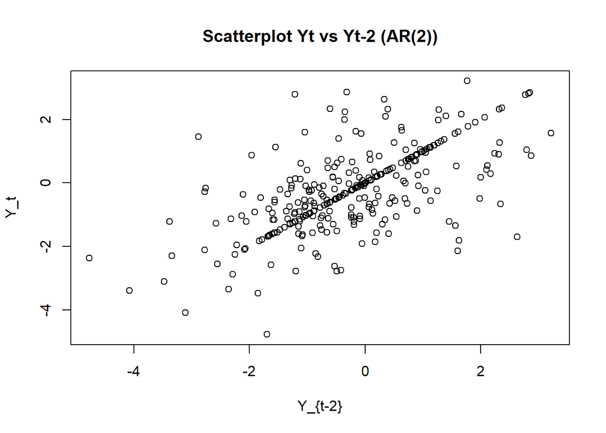

```r
yt_ar2 <- ar2[-c(1,2)]
yt_2_ar2 <- ar2[-c(199,200)]

plot(y = yt_ar2, x = yt_2_ar2,
     main = "Scatterplot Yt vs Yt-2 (AR(2))",
     xlab = "Y_{t-2}", ylab = "Y_t")
```

```r
cor(yt_ar2, yt_2_ar2)
```

```
## [1] 0.6143406
```

Secara teoritis, autokorelasi lag-2 untuk AR(2) adalah:

$$\rho_2 = \phi_1 \rho_1 + \phi_2
= 0.5 \times 0.625 + 0.2
= 0.3125 + 0.2
= 0.5125$$

### Yt vs Yt-3

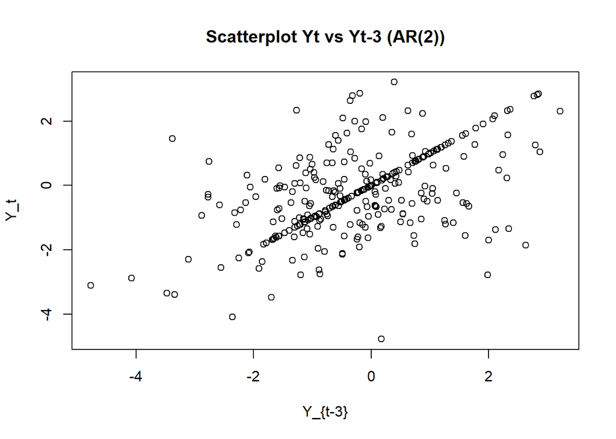

```r
yt_ar2 <- ar2[-c(1,2,3)]
yt_3_ar2 <- ar2[-c(198,199,200)]

plot(y = yt_ar2, x = yt_3_ar2,
     main = "Scatterplot Yt vs Yt-3 (AR(2))",
     xlab = "Y_{t-3}", ylab = "Y_t")
```

```r
cor(yt_ar2, yt_3_ar2)
```

```
## [1] 0.4975126
```

Secara teoritis, autokorelasi lag-3 untuk AR(2) adalah:

$$\rho_3 = \phi_1 \rho_2 + \phi_2 \rho_1
= 0.5 \times 0.5125 + 0.2 \times 0.625
= 0.25625 + 0.125
= 0.38125$$

# Proses ARMA(2,2): phi1 = 0.5, phi2 = 0.2, theta1 = 0.4, theta2 = 0.6

## Pembangkitan Data

### Manual

```r
arma.sim <- function(n, macoef, arcoef){
  manum <- length(macoef)
  arnum <- length(arcoef)
  stopifnot(manum < n & arnum < n)

  wn <- rnorm(n, sd = 0.5)
  init <- max(manum, arnum)

  arma <- wn[1:init]
  for(i in {init+1}:n){
   mastart <- i - manum
   maend <- i-1
   arstart <- i - arnum
   arend <- i-1
   arma[i] <- sum(arcoef * arma[arstart:arend]) + sum(macoef * wn[mastart:maend])  + wn[i]
   }
  return(arma)
}

n <- 300
phi  <- c(0.5, 0.2)
theta <- c(0.4, 0.6)

arma22 <- arma.sim(n = n, macoef = theta, arcoef = phi)
arma22
```

```
##   [1] -0.45913144  0.01100907 -0.34952165  0.20557016  0.04672728  0.08465253
##   [7] -0.29567025 -0.32065149 -0.31170660  0.34933943  0.84781210  0.28124083
##  [13]  1.53267838  0.41905256  0.72223908  0.19594609  0.88368137  0.79609532
##  [19]  0.67817988  0.54073270  0.52476188 -0.27940481  0.50081264  0.38943209
##  [25]  1.01378275  0.73537952  0.41805476  0.81046823 -0.30485941 -0.69033887
##  [31] -1.46241413 -0.49711745 -0.90871442  0.27790131 -0.83257468 -0.01300976
##  [37] -0.37435453  0.67306269  0.39368951  0.50880262 -0.05546731 -0.74911446
##  [43] -0.80289352 -1.77312528 -1.00533017 -1.63259195 -0.75921556 -1.80112030
##  [49] -0.71749955 -2.55489897 -1.23207693 -1.81187263 -0.95631829 -1.70207431
##  [55] -1.52663311 -1.02453230 -0.82920015 -0.58996086 -0.38099855 -0.16920407
##  [61]  0.37187845 -0.04615461 -0.06886591 -0.77856038  0.38045573 -0.01048459
##  [67]  0.35283610  0.34240003 -0.38410059  0.36771300  0.21524158  0.39278098
##  [73] -0.54354746  0.86478767  0.92859084  1.54344347  0.28889191  0.11420807
##  [79] -1.03624044 -0.39189020  0.23766919  0.43347398  0.80364508  0.51205803
##  [85] -0.17221407 -0.68060994 -1.60466460 -1.08946899 -1.40276308 -1.77915415
```

[output cut: 35 more lines]

### Dengan `arima.sim`

```r
arma22_sim <- arima.sim(list(order = c(2,0,2), ar = phi, ma = theta), n = n)
arma22_sim
```

```
## Time Series:
## Start = 1
## End = 300
## Frequency = 1
##   [1] -1.551009402 -0.439532412 -2.044040961 -1.301081931  0.246248333
##   [6]  0.388635317  2.514621060  1.209998412  2.370308705  0.441073867
##  [11]  0.882961857 -0.325264001  0.669181119  1.357392718  1.505514438
##  [16]  1.723185566  1.719094897  2.562921346  3.044990955  3.302782570
##  [21]  3.096423438  2.006015383  2.939438674  2.342209322  3.450578008
##  [26]  0.457731379  1.179762876 -0.103315447  1.340942786 -0.017813164
##  [31]  0.995574825  0.459555044  1.304689291 -0.291161750  0.797810055
##  [36] -0.002799290  0.864771827 -0.521684092  0.299837375  1.463194462
##  [41]  2.206001278  1.462827219  0.297881005 -1.309108076 -2.689172436
##  [46] -2.591781924 -1.903405398 -0.767523493 -1.077809782 -0.222691503
##  [51] -2.043914254 -1.877894295 -2.441156307 -2.938831163 -3.433335376
```

[output cut: 49 more lines]

## Plot Time Series, ACF, PACF, dan EACF

### Plot Time Series

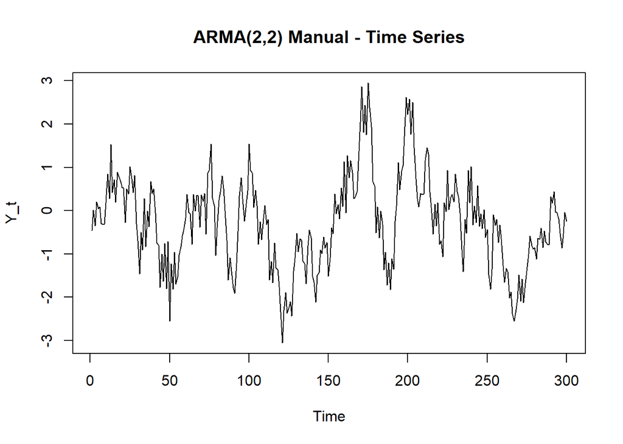

```r
plot.ts(arma22, main = "ARMA(2,2) Manual - Time Series", ylab = "Y_t")
```

> Berdasarkan plot time series, terlihat bahwa data ARMA(2,2) yang dibangkitkan stasioner dalam rataan karena nilai-nilai berfluktuasi di sekitar rata-rata tetap dan tidak menunjukkan adanya tren naik atau turun jangka panjang.

### Plot ACF

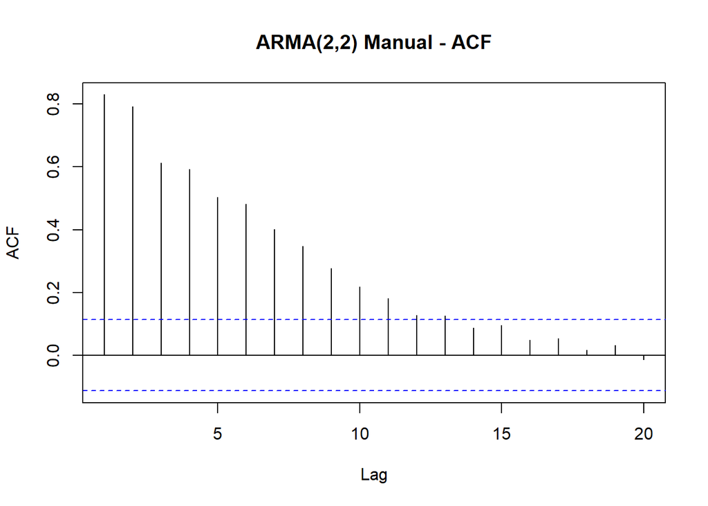

```r
acf(arma22, lag.max = 20, main = "ARMA(2,2) Manual - ACF")
```

> Berdasarkan plot ACF tersebut, terlihat bahwa plot ACF cenderung tails off dan membentuk gelombang sinus, sesuai dengan karakteristik proses ARMA.

### Plot PACF

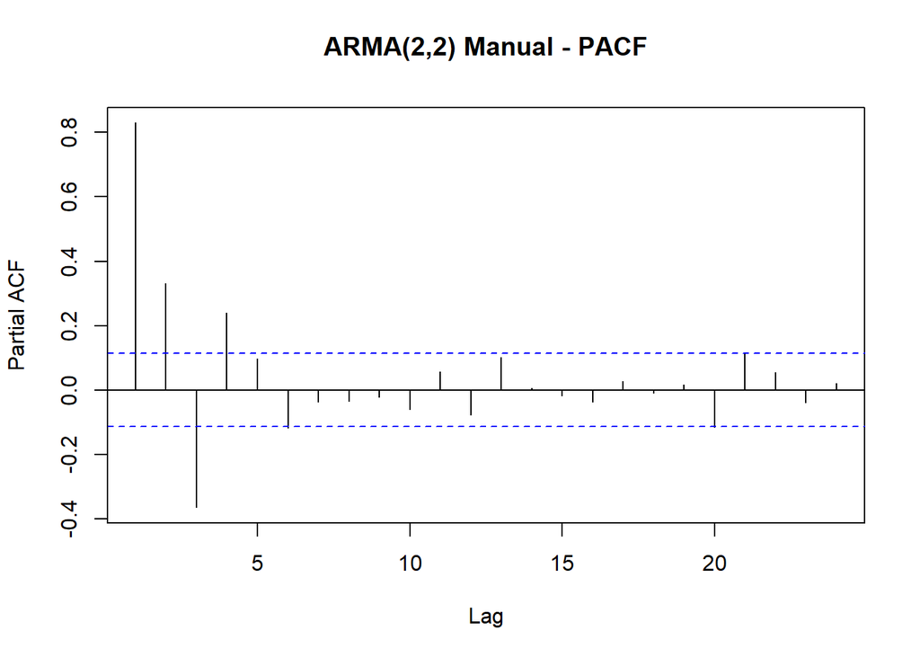

```r
pacf(arma22, main = "ARMA(2,2) Manual - PACF")
```

> Berdasarkan plot PACF tersebut, terlihat bahwa plot PACF cenderung tails off dan membentuk gelombang sinus, sesuai dengan karakteristik proses ARMA.

### Plot EACF

```r
TSA::eacf(arma22)
```

```
## AR/MA
##   0 1 2 3 4 5 6 7 8 9 10 11 12 13
## 0 x x x x x x x x x x x  x  x  o
## 1 x x x x x x o o o o o  x  o  x
## 2 x x x x o x o o o o o  o  o  o
## 3 x x x x o x o o o o o  o  o  o
## 4 x x o x o x o o o o o  o  o  o
## 5 x x o x o o o o o o o  o  o  o
## 6 x x o x o o o o o o o  o  o  o
## 7 x x o o o o o o o o o  o  o  o
```

## Scatterplot Lag dan Autokorelasi

### Yt vs Yt-1

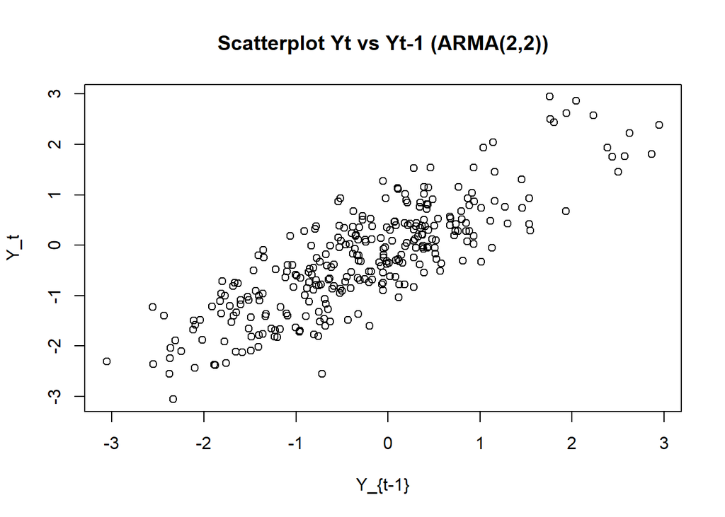

```r
yt_arma22 <- arma22[-1]
yt_1_arma22 <- arma22[-300]

plot(y = yt_arma22, x = yt_1_arma22,
     main = "Scatterplot Yt vs Yt-1 (ARMA(2,2))",
     xlab = "Y_{t-1}", ylab = "Y_t")
```

```r
cor(yt_arma22, yt_1_arma22)
```

```
## [1] 0.8299571
```

Secara teoritis, autokorelasi lag-1 untuk ARMA(2,2) adalah:

Kita gunakan persamaan autokovarians ARMA(2,2) (dengan σ^2 = 1 karena akan saling meniadakan pada rasio ρ_k = γ_k/γ_0):

$$\begin{aligned}
\gamma_0 &= \phi_1 \gamma_1 + \phi_2 \gamma_2 +
(1+\theta_1^2+\theta_2^2),\\
\gamma_1 &= \phi_1 \gamma_0 + \phi_2 \gamma_1 +
(\theta_1+\theta_1\theta_2),\\
\gamma_2 &= \phi_1 \gamma_1 + \phi_2 \gamma_0 + (\theta_2),
\end{aligned}$$
dengan $\phi_1=0.5,\ \phi_2=0.2,\ \theta_1=0.4,\ \theta_2=0.6$.

Hitung konstanta:
$$1+\theta_1^2+\theta_2^2 = 1+0.4^2+0.6^2 = 1.52,\quad
\theta_1+\theta_1\theta_2 = 0.4+0.4\cdot 0.6 = 0.64,\quad
\theta_2=0.6.$$

Substitusi dan selesaikan bertahap:
$$\begin{aligned}
\gamma_1 &= 0.5\,\gamma_0 + 0.2\,\gamma_1 + 0.64
\ \Rightarrow\ 0.8\,\gamma_1 = 0.5\,\gamma_0 + 0.64
\ \Rightarrow\ \gamma_1 = 0.625\,\gamma_0 + 0.8,\\[4pt]
\gamma_2 &= 0.5\,\gamma_1 + 0.2\,\gamma_0 + 0.6
= 0.5(0.625\,\gamma_0 + 0.8) + 0.2\,\gamma_0 + 0.6
= 0.5125\,\gamma_0 + 1.0,\\[4pt]
\gamma_0 &= 0.5\,\gamma_1 + 0.2\,\gamma_2 + 1.52
= 0.5(0.625\,\gamma_0 + 0.8) + 0.2(0.5125\,\gamma_0 + 1.0) + 1.52\\
&= 0.415\,\gamma_0 + 2.12
\ \Rightarrow\ (1-0.415)\gamma_0 = 2.12
\ \Rightarrow\ \gamma_0 = \frac{2.12}{0.585} = \frac{424}{117} \approx
3.62393,\\[4pt]
\gamma_1 &= 0.625\,\gamma_0 + 0.8 = 0.625\cdot \frac{424}{117} + 0.8
= \frac{1793}{585} \approx 3.06496.
\end{aligned}$$

Maka
$$\rho_1 = \frac{\gamma_1}{\gamma_0}
= \frac{1793/585}{424/117}
\approx 0.8458.$$

Nilai korelasi dari simulasi (0.830) cukup mendekati nilai teoritis 0.8458

### Yt vs Yt-2

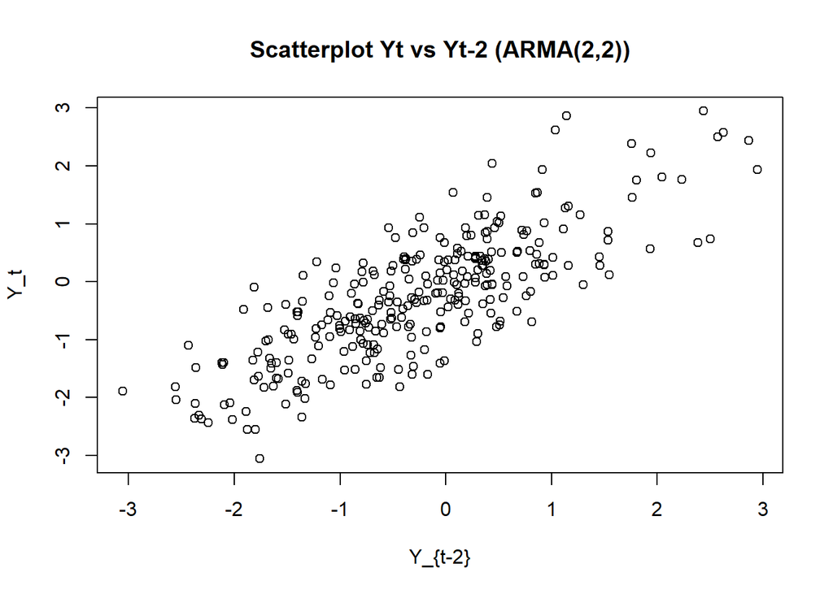

```r
yt_arma22 <- arma22[-c(1,2)]
yt_2_arma22 <- arma22[-c(299,300)]

plot(y = yt_arma22, x = yt_2_arma22,
     main = "Scatterplot Yt vs Yt-2 (ARMA(2,2))",
     xlab = "Y_{t-2}", ylab = "Y_t")
```

```r
cor(yt_arma22, yt_2_arma22)
```

```
## [1] 0.7919494
```

Secara teoritis, autokorelasi lag-2 untuk ARMA(2,2) adalah:

Gunakan persamaan autokovarians ARMA(2,2) (ambil sigma^2 = 1 karena akan saling meniadakan pada rasio $\rho_k=\gamma_k/\gamma_0$):

$$\begin{aligned}
\gamma_0 &= \phi_1 \gamma_1 + \phi_2 \gamma_2 +
(1+\theta_1^2+\theta_2^2),\\
\gamma_1 &= \phi_1 \gamma_0 + \phi_2 \gamma_1 +
(\theta_0\theta_1+\theta_1\theta_2),\\
\gamma_2 &= \phi_1 \gamma_1 + \phi_2 \gamma_0 + (\theta_0\theta_2),
\end{aligned}$$
dengan $\theta_0=1$ dan $\phi_1=0.5,\ \phi_2=0.2,\ \theta_1=0.4,\ \theta_2=0.6$.

Hitung konstanta:
$$1+\theta_1^2+\theta_2^2 = 1+0.4^2+0.6^2 = 1.52,\quad
\theta_0\theta_1+\theta_1\theta_2 = 0.4+0.4\cdot 0.6 = 0.64,\quad
\theta_0\theta_2=0.6.$$

Substitusi dan selesaikan bertahap:
$$\begin{aligned}
\gamma_1 &= 0.5\,\gamma_0 + 0.2\,\gamma_1 + 0.64
\ \Rightarrow\ \gamma_1 = 0.625\,\gamma_0 + 0.8,\\[4pt]
\gamma_2 &= 0.5\,\gamma_1 + 0.2\,\gamma_0 + 0.6
= 0.5(0.625\,\gamma_0 + 0.8) + 0.2\,\gamma_0 + 0.6
= 0.5125\,\gamma_0 + 1.0,\\[4pt]
\gamma_0 &= 0.5\,\gamma_1 + 0.2\,\gamma_2 + 1.52
= 0.415\,\gamma_0 + 2.12
\ \Rightarrow\ \gamma_0 = \frac{2.12}{0.585} = \frac{424}{117}.
\end{aligned}$$

Maka
$$\gamma_2 = 0.5125\,\gamma_0 + 1
= \frac{41}{80}\cdot \frac{424}{117} + 1
= \frac{3343}{1170},
\quad
\rho_2 = \frac{\gamma_2}{\gamma_0}
= \frac{\tfrac{3343}{1170}}{\tfrac{424}{117}}
= \frac{3343}{4240}
\approx 0.7884.$$

Nilai korelasi dari simulasi (0.792) cukup mendekati nilai teoritis 0.7884

### Yt vs Yt-3

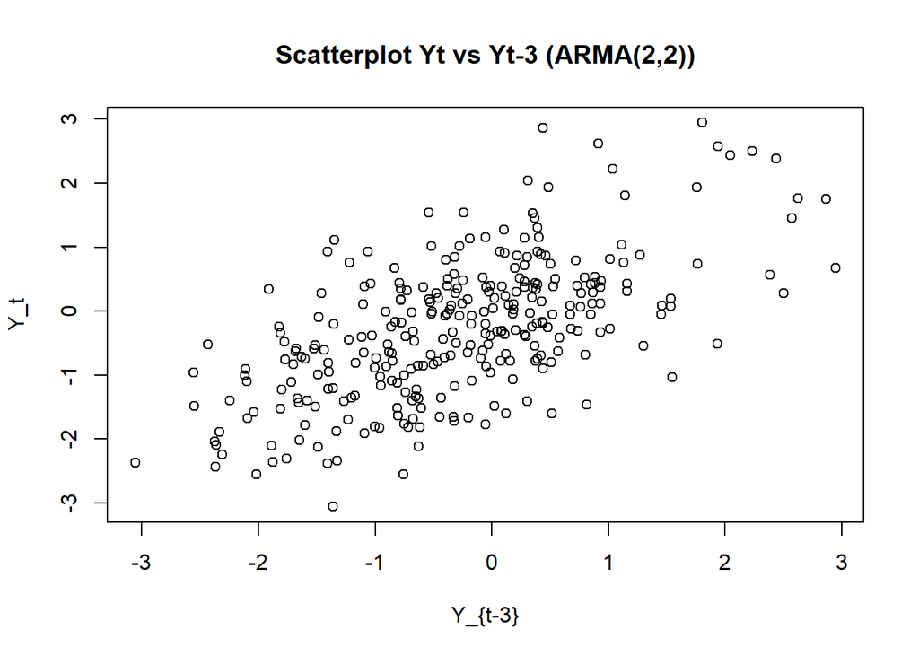

```r
yt_arma22 <- arma22[-c(1,2,3)]
yt_3_arma22 <- arma22[-c(298,299,300)]

plot(y = yt_arma22, x = yt_3_arma22,
     main = "Scatterplot Yt vs Yt-3 (ARMA(2,2))",
     xlab = "Y_{t-3}", ylab = "Y_t")
```

```r
cor(yt_arma22, yt_3_arma22)
```

```
## [1] 0.6133161
```

Secara teoritis, autokorelasi lag-3 untuk ARMA(2,2) adalah:

Gunakan persamaan autokovarians ARMA(2,2) (ambil σ² = 1 karena akan saling meniadakan pada rasio $\rho_k=\gamma_k/\gamma_0$):

$$\begin{aligned}
\gamma_0 &= \phi_1 \gamma_1 + \phi_2 \gamma_2 +
(1+\theta_1^2+\theta_2^2),\\
\gamma_1 &= \phi_1 \gamma_0 + \phi_2 \gamma_1 +
(\theta_1+\theta_1\theta_2),\\
\gamma_2 &= \phi_1 \gamma_1 + \phi_2 \gamma_0 + (\theta_2),
\end{aligned}$$
dengan $\phi_1=0.5,\ \phi_2=0.2,\ \theta_1=0.4,\ \theta_2=0.6$.

Dari tiga persamaan di atas diperoleh (tepat dalam pecahan):
$$\gamma_0=\frac{424}{117},\quad
\gamma_1=\frac{1793}{585},\quad
\gamma_2=\frac{3343}{1170}.$$

Karena $3>q$, maka untuk $k=3$ tidak ada suku MA:
$$\gamma_3=\phi_1\gamma_2+\phi_2\gamma_1
= \tfrac{1}{2}\cdot \tfrac{3343}{1170} + \tfrac{1}{5}\cdot
\tfrac{1793}{585}
= \frac{23887}{11700}.$$

Maka
$$\rho_3=\frac{\gamma_3}{\gamma_0}
= \frac{\tfrac{23887}{11700}}{\tfrac{424}{117}}
= \frac{23887}{42400}
\approx 0.56336.$$

Nilai korelasi dari simulasi (0.613) cukup mendekati nilai teoritis 0.56336